# Lab 3 - 19001395 - V

Otto Chamo

# Ejercicio 1

Utilizando R realice una función que dado un dataframe cualquiera de dos columnas, donde la primera (índice 1) sea el valor de la variable independiente (X) y la segunda sea el valor de una variable dependiente (Y), devuelva una lista con los siguientes elementos:

## 1) Un arreglo con lo valores de los estimadores para $B_0$ y $B_1$

```r
calculate_estimators <- function(df) {
  x <- df[, 1]
  y <- df[, 2]
  n <- length(x)

  num_b1 <- (sum(x) * sum(y) - n * (sum(x * y)))
  denominator_b1 <- ((sum(x)^2) - n * sum(x^2))
  b1 <- num_b1 / denominator_b1

  num_b0 <- (sum(y) - b1 * (sum(x)))
  b0 <- num_b0 / length(x)

  result <- list(B_0 = b0, B_1 = b1)
  return(result)
}


calculate_r_squared <- function(df, estimators) {
  x <- df[, 1]
  y <- df[, 2]

  y_pred <- estimators$B_0 + estimators$B_1 * x

  mean_y <- mean(y)


  r_squared_num <- sum((y_pred - mean_y)^2)
  r_squared_den <- sum((y - mean_y)^2)
  s <- y - mean_y
  r2 <- r_squared_num / r_squared_den

  return(r2)

}

calculate_r <- function(r2) {
  return(sqrt(r2))
}

calculate_residuals <- function(df, estimators) {
  x <- df[, 1]
  y <- df[, 2]

  y_pred <- estimators$B_0 + estimators$B_1 * x

  residuals <- y - y_pred

  return(y_pred)
}
```

```r
randomDf <- data.frame(
  X = c(3, 4, 5, 7, 8),
  Y = c(2, 4, 5, 4, 5)
)

estimators <- calculate_estimators(randomDf)
print(estimators)
```

```
$B_0
[1] 1.802326

$B_1
[1] 0.4069767
```

```r
model <- lm(randomDf[, 2] ~ randomDf[, 1])
summary(model)
```

```
Call:
lm(formula = randomDf[, 2] ~ randomDf[, 1])

Residuals:
       1        2        3        4        5
-1.02326  0.56977  1.16279 -0.65116 -0.05814

Coefficients:
              Estimate Std. Error t value Pr(>|t|)
(Intercept)     1.8023     1.4110   1.277    0.291
randomDf[, 1]   0.4070     0.2471   1.647    0.198

Residual standard error: 1.025 on 3 degrees of freedom
Multiple R-squared:  0.4748,    Adjusted R-squared:  0.2997
F-statistic: 2.712 on 1 and 3 DF,  p-value: 0.1981
```

## 2) El valor del coeficiente de determinación $r^2$ del modelo.

```r
r2 <- calculate_r_squared(randomDf, estimators)
print(r2)
```

```
[1] 0.4748062
```

## 3) El coeficiente de correlación r (raíz cuadrada de $r^2$)

```r
r_coef <- calculate_r(r2)
print(r_coef)
```

```
[1] 0.6890618
```

```r
residuals <- calculate_residuals(randomDf, estimators)

print(residuals)
```

[output not shown]

## 5) Una gráfica con la nube de puntos y la recta de regresión del modelo

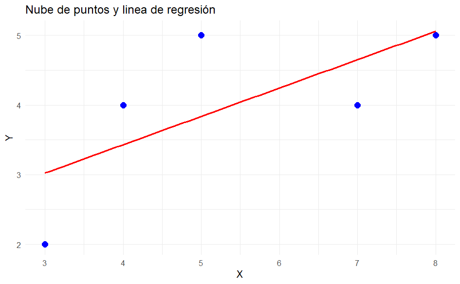

```r
regression_line <- function(df, estimators) {
  x_seq <- seq(min(df[, 1]), max(df[, 1]), length.out = 100)

  y_pred <- estimators$B_0 + estimators$B_1 * x_seq

  regressionLine <- data.frame(X = x_seq, Y = y_pred)

  return(regressionLine)
}

regressionLine <- regression_line(randomDf, estimators)

regressionLinePlot <- ggplot(randomDf, aes(x = X, y = Y)) +
        geom_point(color = "blue", size=3) +
        geom_line(data = regressionLine, aes(x = X, y = Y), color = "red", size = 1) +
        labs(title = "Nube de puntos y linea de regresión",
             x = "X",
             y = "Y"
        ) +
        theme_minimal()

print(regressionLinePlot)
```

# Ejercicio 2

## 1. Realice un análisis estadístico sobre todas las variables del dataset, recuerde que pude usar la función summary().

```r
admissionsDatasetPath <- "Admisions.csv"

admissionsDf <- read.csv(admissionsDatasetPath)

head(admissionsDf)
```

|  | Serial.No. | GRE.Score | TOEFL.Score | University.Rating | SOP | LOR | CGPA | Research | Chance.of.Admit |
| --- | --- | --- | --- | --- | --- | --- | --- | --- | --- |
| 1 | 1 | 337 | 118 | 4 | 4.5 | 4.5 | 9.65 | 1 | 0.92 |
| 2 | 2 | 324 | 107 | 4 | 4.0 | 4.5 | 8.87 | 1 | 0.76 |
| 3 | 3 | 316 | 104 | 3 | 3.0 | 3.5 | 8.00 | 1 | 0.72 |
| 4 | 4 | 322 | 110 | 3 | 3.5 | 2.5 | 8.67 | 1 | 0.80 |
| 5 | 5 | 314 | 103 | 2 | 2.0 | 3.0 | 8.21 | 0 | 0.65 |
| 6 | 6 | 330 | 115 | 5 | 4.5 | 3.0 | 9.34 | 1 | 0.90 |

```r
summary(admissionsDf)
```

```
   Serial.No.      GRE.Score      TOEFL.Score    University.Rating      SOP             LOR             CGPA          Research
 Min.   :  1.0   Min.   :290.0   Min.   : 92.0   Min.   :1.000     Min.   :1.000   Min.   :1.000   Min.   :6.800   Min.   :0.00
 1st Qu.:125.8   1st Qu.:308.0   1st Qu.:103.0   1st Qu.:2.000     1st Qu.:2.500   1st Qu.:3.000   1st Qu.:8.127   1st Qu.:0.00
 Median :250.5   Median :317.0   Median :107.0   Median :3.000     Median :3.500   Median :3.500   Median :8.560   Median :1.00
 Mean   :250.5   Mean   :316.5   Mean   :107.2   Mean   :3.114     Mean   :3.374   Mean   :3.484   Mean   :8.576   Mean   :0.56
 3rd Qu.:375.2   3rd Qu.:325.0   3rd Qu.:112.0   3rd Qu.:4.000     3rd Qu.:4.000   3rd Qu.:4.000   3rd Qu.:9.040   3rd Qu.:1.00
 Max.   :500.0   Max.   :340.0   Max.   :120.0   Max.   :5.000     Max.   :5.000   Max.   :5.000   Max.   :9.920   Max.   :1.00
 Chance.of.Admit
 Min.   :0.3400
 1st Qu.:0.6300
 Median :0.7200
 Mean   :0.7217
 3rd Qu.:0.8200
 Max.   :0.9700
```

Podemos notar que no todas las variables tienen la misma escala, unas tienes valores mucho más bajos que otros, este tipo de condiciones puede llevar a problemas de entrenamiento en el modelo, porque puede asignarle mayor importancia a algunas variables que no tienen tanta relevancia, deberiamos llevarlos todos a una misma escala.

## 2. Realice una gráfica de densidad para cada una de las variables numéricas en el dataset: GRE.Score, TOEFEL.Score, CGPA y Chance of Admit

```r
plotColumn <- function(data, x_axis, title, x_lab, y_lab) {
  plottedDensity <- ggplot(data, aes(x = x_axis)) +
  geom_density(fill = "blue", alpha = 0.5) +
  labs(title = title, x = x_lab, y = y_lab)

  return(plottedDensity)
}
```

### Gráfica de densidad GRE Score

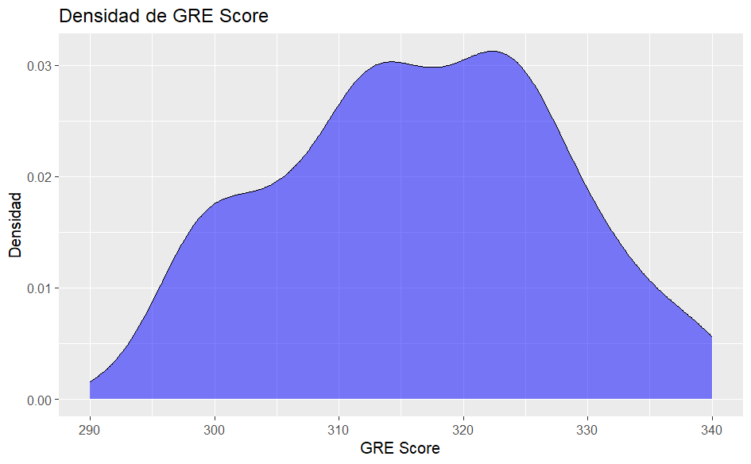

```r
plotColumn(admissionsDf, admissionsDf$GRE.Score, "Densidad de GRE Score", x_lab="GRE Score", y_lab = "Densidad")
```

### Gráfica de densidad de TOEFEL Score

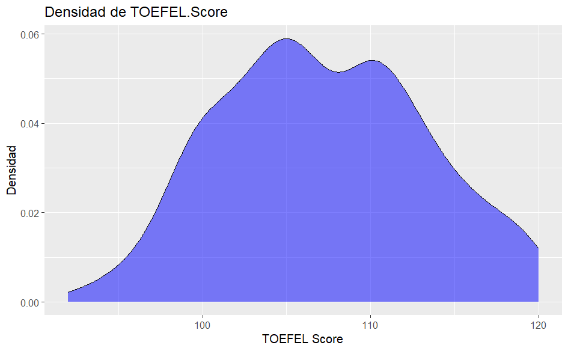

```r
plotColumn(admissionsDf, admissionsDf$TOEFL.Score, "Densidad de TOEFEL.Score", x_lab = "TOEFEL Score", "Densidad")
```

### Gráfica de densidad de CGPA

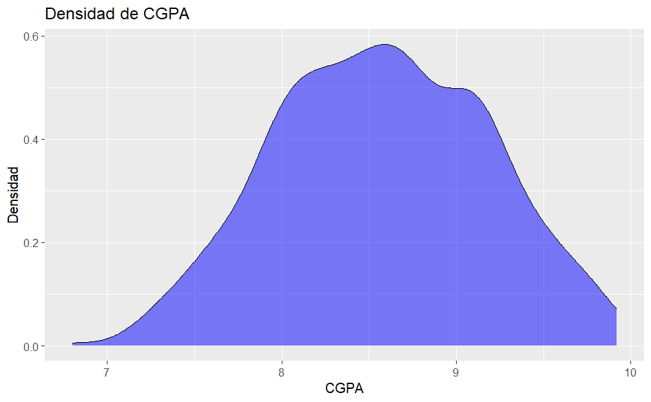

```r
plotColumn(admissionsDf, admissionsDf$CGPA, "Densidad de CGPA", x_lab = "CGPA", y_lab = "Densidad")
```

### Gráfica de densidad de Chance of Admit

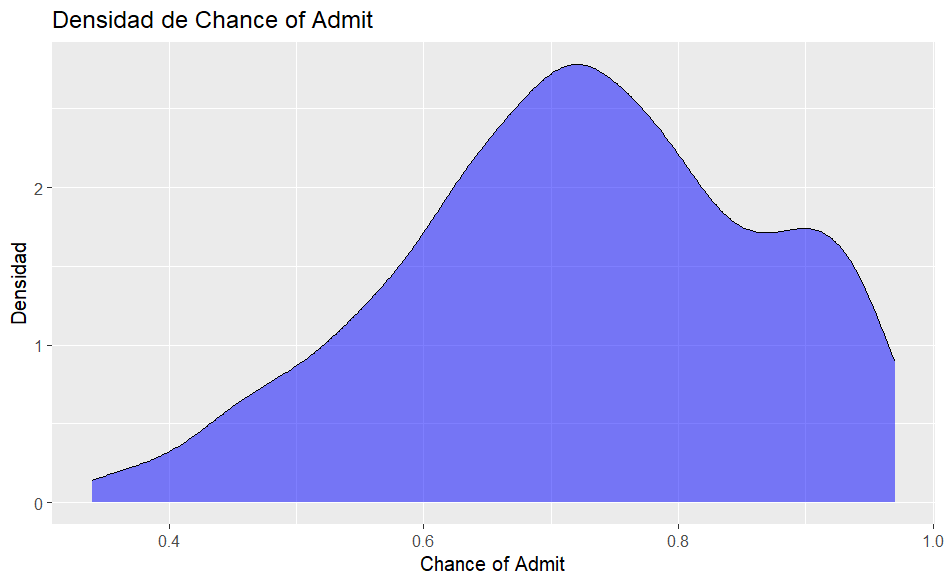

```r
plotColumn(admissionsDf, admissionsDf$Chance.of.Admit, "Densidad de Chance of Admit", x_lab = "Chance of Admit", y_lab = "Densidad")
```

## 3. Realice una gráfica de correlación entre las variables del inciso

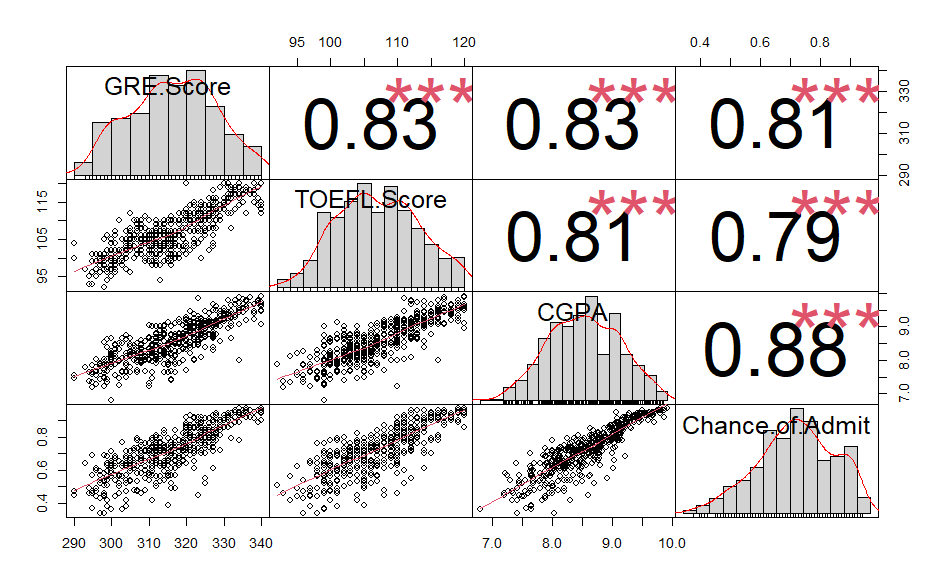

```r
columnsToPlotDf <- admissionsDf %>%
  select(GRE.Score, TOEFL.Score, CGPA, Chance.of.Admit)



chart.Correlation(columnsToPlotDf, histogram = TRUE, method = "pearson")
```

## 4. Realice comentarios sobre el análisis estadístico de las variable numéricas y la gráfica de correlación

Podemos ver que exista una alta correlación entre las variables, pero la que mejor predice el chance de admisión es la de CGPA. Todas las correlaciones son positivas y podemos que casi tienen una distribucón normal.

## 5. Realice un scatter plot (nube de puntos) de todas las variables numéricas contra la variable Chance of Admit

```r
scatterPlotGenerator <- function(data, x, y, title, x_lab, y_lab) {

  scatterPlot <- ggplot(data, aes(x = x, y = y)) +
  geom_point(alpha = 0.5) +
  geom_smooth(method = "lm", se = TRUE, color = "blue") +
  labs(title = title, x = x_lab, y = y_lab) +
  theme_minimal()
  return(scatterPlot)
}
```

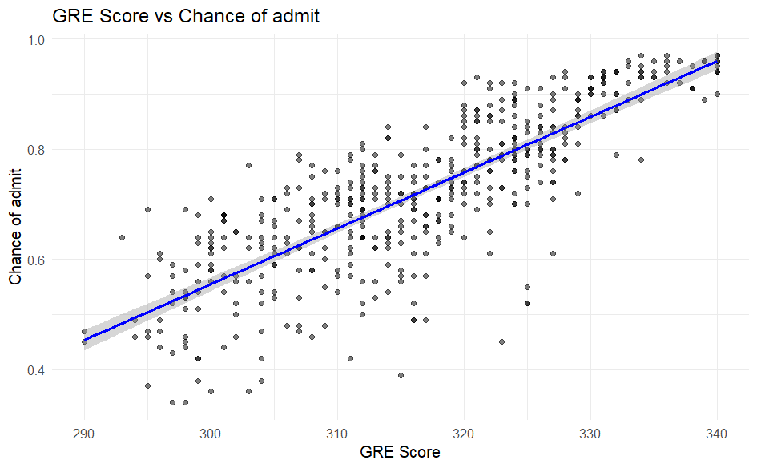

```r
scatterPlotGenerator(
  admissionsDf,
  x = admissionsDf$GRE.Score,
  y = admissionsDf$Chance.of.Admit,
  title = "GRE Score vs Chance of admit",
  x_lab = "GRE Score",
  y_lab = "Chance of admit"
)
```

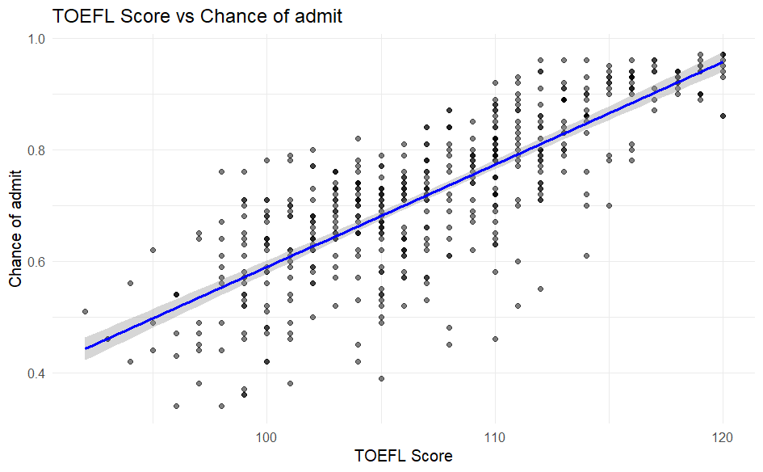

```r
scatterPlotGenerator(
  admissionsDf,
  x = admissionsDf$TOEFL.Score,
  y = admissionsDf$Chance.of.Admit,
  title = "TOEFL Score vs Chance of admit",
  x_lab = "TOEFL Score",
  y_lab = "Chance of admit"
)
```

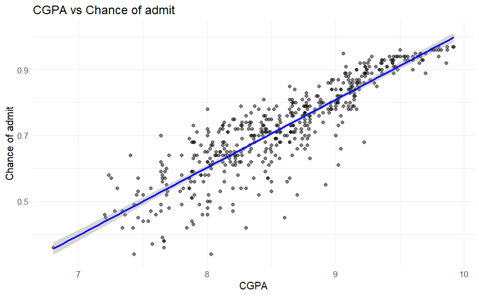

```r
scatterPlotGenerator(
  admissionsDf,
  x = admissionsDf$CGPA,
  y = admissionsDf$Chance.of.Admit,
  title = "CGPA vs Chance of admit",
  x_lab = "CGPA",
  y_lab = "Chance of admit"
)
```

## 6. Utilizando la función train y trainControl para crear un cross-validation y le permita evaluar los siguientes modelos

```r
createLrModel <- function(data, formula) {
  train_control <- trainControl(method = "cv", number = 10)

  lr_model <- train(formula, data = data, method = "lm", trControl = train_control)

  return(lr_model)
}

chanceOfAdmit <- "Chance.of.Admit"
```

### Chance of Admit ~ TOEFEL.Score.

```r
toefl_model <- createLrModel(admissionsDf, as.formula("Chance.of.Admit ~ TOEFL.Score"))

print(toefl_model)
```

```
Linear Regression

500 samples
  1 predictor

No pre-processing
Resampling: Cross-Validated (10 fold)
Summary of sample sizes: 450, 448, 449, 451, 452, 450, ...
Resampling results:

  RMSE        Rsquared   MAE
  0.08566017  0.6395572  0.06678002

Tuning parameter 'intercept' was held constant at a value of TRUE
```

```r
summary(toefl_model)
```

```
Call:
lm(formula = .outcome ~ ., data = dat)

Residuals:
     Min       1Q   Median       3Q      Max
-0.31337 -0.04990  0.01310  0.05633  0.20725

Coefficients:
              Estimate Std. Error t value Pr(>|t|)
(Intercept) -1.2489882  0.0681317  -18.33   <2e-16 ***
TOEFL.Score  0.0183850  0.0006346   28.97   <2e-16 ***
---
Signif. codes:  0 ‘***’ 0.001 ‘**’ 0.01 ‘*’ 0.05 ‘.’ 0.1 ‘ ’ 1

Residual standard error: 0.08621 on 498 degrees of freedom
Multiple R-squared:  0.6276,    Adjusted R-squared:  0.6269
F-statistic: 839.4 on 1 and 498 DF,  p-value: < 2.2e-16
```

### Chance of Admit ~ CGPA.

```r
cgpa_model <- createLrModel(admissionsDf, as.formula("Chance.of.Admit ~ CGPA"))
print(cgpa_model)
```

```
Linear Regression

500 samples
  1 predictor

No pre-processing
Resampling: Cross-Validated (10 fold)
Summary of sample sizes: 450, 451, 451, 449, 451, 451, ...
Resampling results:

  RMSE        Rsquared   MAE
  0.06620922  0.7796114  0.0486108

Tuning parameter 'intercept' was held constant at a value of TRUE
```

```r
summary(cgpa_model)
```

```
Call:
lm(formula = .outcome ~ ., data = dat)

Residuals:
      Min        1Q    Median        3Q       Max
-0.276592 -0.028169  0.006619  0.038483  0.176961

Coefficients:
            Estimate Std. Error t value Pr(>|t|)
(Intercept) -1.04434    0.04230  -24.69   <2e-16 ***
CGPA         0.20592    0.00492   41.85   <2e-16 ***
---
Signif. codes:  0 ‘***’ 0.001 ‘**’ 0.01 ‘*’ 0.05 ‘.’ 0.1 ‘ ’ 1

Residual standard error: 0.06647 on 498 degrees of freedom
Multiple R-squared:  0.7787,    Adjusted R-squared:  0.7782
F-statistic:  1752 on 1 and 498 DF,  p-value: < 2.2e-16
```

### Chance of Admit ~ GRE.Score.

```r
greScore_model <- createLrModel(admissionsDf, as.formula("Chance.of.Admit ~ GRE.Score"))
print(greScore_model)
```

```
Linear Regression

500 samples
  1 predictor

No pre-processing
Resampling: Cross-Validated (10 fold)
Summary of sample sizes: 451, 450, 450, 448, 450, 450, ...
Resampling results:

  RMSE        Rsquared   MAE
  0.08231702  0.6677704  0.06277577

Tuning parameter 'intercept' was held constant at a value of TRUE
```

```r
summary(greScore_model)
```

```
Call:
lm(formula = .outcome ~ ., data = dat)

Residuals:
     Min       1Q   Median       3Q      Max
-0.33784 -0.04479  0.00417  0.05449  0.18568

Coefficients:
              Estimate Std. Error t value Pr(>|t|)
(Intercept) -2.4828147  0.1038994  -23.90   <2e-16 ***
GRE.Score    0.0101259  0.0003281   30.86   <2e-16 ***
---
Signif. codes:  0 ‘***’ 0.001 ‘**’ 0.01 ‘*’ 0.05 ‘.’ 0.1 ‘ ’ 1

Residual standard error: 0.08278 on 498 degrees of freedom
Multiple R-squared:  0.6567,    Adjusted R-squared:  0.656
F-statistic: 952.5 on 1 and 498 DF,  p-value: < 2.2e-16
```

```r
toeflCgpaModel <- createLrModel(admissionsDf, as.formula("Chance.of.Admit ~ TOEFL.Score + GRE.Score"))
print(toeflCgpaModel)
```

```
Linear Regression

500 samples
  2 predictor

No pre-processing
Resampling: Cross-Validated (10 fold)
Summary of sample sizes: 450, 451, 449, 450, 449, 451, ...
Resampling results:

  RMSE        Rsquared   MAE
  0.07648391  0.7095426  0.05843305

Tuning parameter 'intercept' was held constant at a value of TRUE
```

```r
summary(toeflCgpaModel)
```

```
Call:
lm(formula = .outcome ~ ., data = dat)

Residuals:
     Min       1Q   Median       3Q      Max
-0.31903 -0.03969  0.01197  0.04904  0.15750

Coefficients:
              Estimate Std. Error t value Pr(>|t|)
(Intercept) -2.1802676  0.1024365 -21.284   <2e-16 ***
TOEFL.Score  0.0089600  0.0010084   8.886   <2e-16 ***
GRE.Score    0.0061350  0.0005429  11.300   <2e-16 ***
---
Signif. codes:  0 ‘***’ 0.001 ‘**’ 0.01 ‘*’ 0.05 ‘.’ 0.1 ‘ ’ 1

Residual standard error: 0.07698 on 497 degrees of freedom
Multiple R-squared:  0.7037,    Adjusted R-squared:  0.7025
F-statistic: 590.3 on 2 and 497 DF,  p-value: < 2.2e-16
```